# 1. Distribuciones muestrales

Inferencia Estadística · Caso de estudio: atropellamientos en la CDMX

*Temario: unidad 1 (Inferencia Estadística, clave 1541).*

## 1.1 Población, muestra y estadística

- **Población:** todos los intervalos entre atropellamientos en hora pico de días laborables.
- **Muestra:** los intervalos de un mes.
- **Estadística:** cualquier función de la muestra, como la media $\bar X$. Como la muestra es aleatoria, $\bar X$ también lo es: cada mes da un valor distinto.

```r
atropellamientos <- leer_atropellamientos()
limpios <- hora_pico(atropellamientos) |> depurar_duplicados()
meses <- format(seq(as.Date("2022-01-01"), as.Date("2023-12-01"), by = "month"), "%Y-%m")
por_mes <- tibble(mes = meses,
                  n = sapply(meses, function(m) length(tiempos_mes(limpios, m))),
                  media = sapply(meses, function(m) mean(tiempos_mes(limpios, m))))
summary(por_mes$media)
```

```
##    Min. 1st Qu.  Median    Mean 3rd Qu.    Max.
##   26.99   33.79   36.62   37.01   40.28   49.34
```

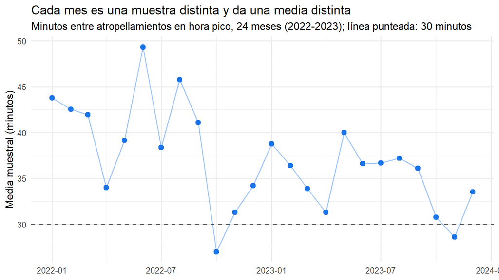

```r
ggplot(por_mes, aes(as.Date(paste0(mes, "-01")), media)) +
  geom_hline(yintercept = 30, linetype = 2, colour = "grey40") +
  geom_point(size = 2.5, colour = "#1a73e8") + geom_line(colour = "#1a73e8", alpha = 0.4) +
  labs(x = NULL, y = "Media muestral (minutos)",
       title = "Cada mes es una muestra distinta y da una media distinta",
       subtitle = "Minutos entre atropellamientos en hora pico, 24 meses (2022-2023); línea punteada: 30 minutos")
```

¿Toda esta variación es azar, o hay meses en que de verdad atropellan más? Esa pregunta la contestamos en el capítulo 2. Aquí empezamos por la parte que sí es azar: cuánto varía $\bar X$ aunque $\mu$ no cambie.

La pregunta de esta unidad: **¿cómo se distribuye $\bar X$?** Si lo sabemos, sabremos cuánto puede alejarse de $\mu$ solo por azar.

## 1.2 Distribuciones muestrales

### 1.2.1 Distribuciones de las estadísticas muestrales bajo normalidad

Los resultados clásicos suponen que $X_1, \dots, X_n$ son independientes con distribución $N(\mu, \sigma^2)$. En ese caso:

- $\bar X \sim N(\mu, \sigma^2/n)$;
- $(n-1)S^2/\sigma^2 \sim \chi^2_{n-1}$, independiente de $\bar X$;
- $\dfrac{\bar X - \mu}{S/\sqrt n} \sim t_{n-1}$;
- el cociente de las varianzas muestrales de dos muestras normales independientes, cada una dividida entre su $\sigma^2$, tiene distribución $F$.

Son la base de las pruebas t y F. Pero nuestros tiempos **no son normales**: son muy asimétricos. ¿Qué pasa si usamos esos resultados de todos modos? Simulamos muestras de tamaño 10 de una normal y de una exponencial, con la misma media y varianza, y vemos con qué frecuencia cada estadística cae en las colas de 2.5% que predice la teoría normal (deberían ser 5% en total):

```r
B <- 20000; k <- 10
colas <- function(generar, mu, sigma) {
  r <- replicate(B, { y <- generar()
    c(t = (mean(y) - mu) / (sd(y) / sqrt(k)), ji = (k - 1) * var(y) / sigma^2) })
  c(t = mean(abs(r["t", ]) > qt(0.975, k - 1)),
    ji_cuadrada = mean(r["ji", ] < qchisq(0.025, k - 1) | r["ji", ] > qchisq(0.975, k - 1)))
}
round(rbind(normal = colas(function() rnorm(k, 35, 35), 35, 35),
            exponencial = colas(function() rexp(k, 1 / 35), 35, 35)), 3)
```

```
##                 t ji_cuadrada
## normal      0.052       0.050
## exponencial 0.102       0.236
```

Con datos normales, ambas estadísticas caen en las colas el 5% de las veces, como dice la teoría. Con datos exponenciales, la t cae en las colas el doble de veces (10%) y la estadística de la varianza casi cinco veces más (24%). Los resultados bajo normalidad **no se pueden usar a ciegas**: necesitamos la distribución muestral que corresponde a nuestro modelo.

### La media de una muestra exponencial

Si $X_1, \dots, X_n$ son independientes con distribución exponencial de media $\mu$, la suma es gamma y, por lo tanto,

$$\bar X \sim \text{Gamma}\left(n, \ \text{tasa} = \frac{n}{\mu}\right),
\qquad E[\bar X] = \mu, \qquad \operatorname{Var}(\bar X) =
\frac{\mu^2}{n}.$$

En el capítulo 2 comprobaremos que el modelo exponencial es razonable en hora pico. Por ahora, verifiquemos el resultado por simulación con valores parecidos a los de nuestros datos: $\mu = 35$ minutos y $n = 120$ intervalos.

```r
mu <- 35; n <- 120; B <- 20000
medias <- replicate(B, mean(rexp(n, rate = 1 / mu)))

c(media_simulada = mean(medias), teorica = mu)
```

```
## media_simulada        teorica
##       35.02494       35.00000
```

```r
c(sd_simulada = sd(medias), teorica = mu / sqrt(n))
```

```
## sd_simulada     teorica
##    3.195178    3.195048
```

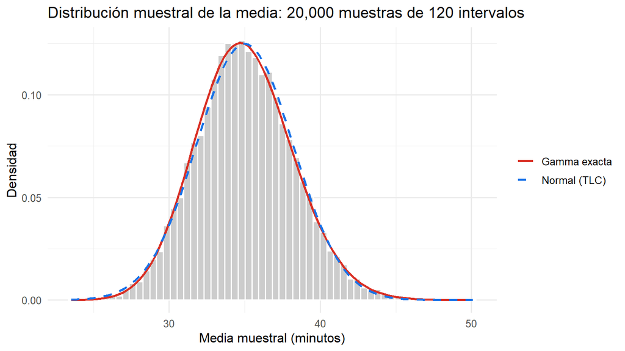

```r
ggplot(data.frame(medias), aes(medias)) +
  geom_histogram(aes(y = after_stat(density)), bins = 60, fill = "grey80", colour = "white") +
  stat_function(fun = dgamma, args = list(shape = n, rate = n / mu), aes(colour = "Gamma exacta"), linewidth = 1) +
  stat_function(fun = dnorm, args = list(mean = mu, sd = mu / sqrt(n)), aes(colour = "Normal (TLC)"), linewidth = 1, linetype = 2) +
  scale_colour_manual(values = c("Gamma exacta" = "#d93025", "Normal (TLC)" = "#1a73e8"), name = NULL) +
  labs(x = "Media muestral (minutos)", y = "Densidad",
       title = "Distribución muestral de la media: 20,000 muestras de 120 intervalos")
```

Con $n = 120$ la gamma y la normal casi coinciden (teorema del límite central). Con muestras chicas no:

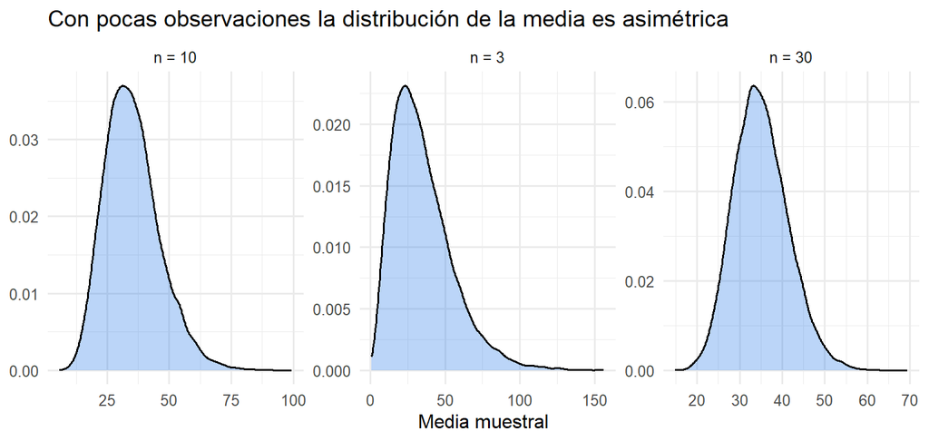

```r
compara <- bind_rows(lapply(c(3, 10, 30), function(k) {
  tibble(n = paste("n =", k), media = replicate(B, mean(rexp(k, 1 / mu))))
}))
ggplot(compara, aes(media)) +
  geom_density(fill = "#1a73e8", alpha = 0.3) +
  facet_wrap(~ n, scales = "free") +
  labs(x = "Media muestral", y = NULL, title = "Con pocas observaciones la distribución de la media es asimétrica")
```

**Para llevar al resto del curso.** La cantidad $2n\bar X / \mu$ tiene distribución $\chi^2_{2n}$ sin importar el valor de $\mu$ (es un *pivote*). La usaremos en el capítulo 4 para construir un intervalo de confianza exacto.

```r
pivote <- 2 * n * medias / mu
ks.test(pivote, "pchisq", df = 2 * n)$p.value  # compatible con una ji cuadrada de 2n grados
```

```
## [1] 0.2241433
```

### 1.2.2 Distribución de las estadísticas de orden

**El mínimo.** Supongamos que dividimos la ciudad en $k$ zonas independientes, cada una con atropellamientos exponenciales de media $\mu_j$. El tiempo hasta el **primer** atropellamiento en cualquier zona es el mínimo, y

$$\min(X_1, \dots, X_k) \sim \text{Exponencial}\left(\text{tasa} = \sum_j
\frac{1}{\mu_j}\right).$$

Por eso, aunque en cada alcaldía los atropellamientos sean poco frecuentes, en la ciudad entera ocurren cada pocos minutos.

```r
mu_zona <- 16 * 35          # 16 alcaldías iguales con la misma tasa total de la ciudad
minimos <- replicate(B, min(rexp(16, rate = 1 / mu_zona)))
c(media_simulada = mean(minimos), teorica = mu_zona / 16)
```

```
## media_simulada        teorica
##        34.8726        35.0000
```

**El máximo.** El intervalo más largo de una muestra, $X_{(n)}$, tiene función de distribución $F(x)^n$. Sirve para preguntas como “¿es raro pasar una hora sin atropellamientos?”.

```r
x <- muestra_curso(atropellamientos)
c(maximo_observado = max(x),
  probabilidad_de_superarlo = 1 - pexp(max(x), rate = 1 / mean(x))^length(x))
```

```
##          maximo_observado probabilidad_de_superarlo
##               152.8333333                 0.7373787
```

## Lo que ya sabemos y lo que falta

- Los resultados clásicos bajo normalidad ($t$, $\chi^2$, $F$) no aplican a ciegas a datos asimétricos como los nuestros.
- La media de un mes cambia de un mes a otro; su variabilidad depende de $\mu$ y de $n$: $\operatorname{sd}(\bar X) = \mu / \sqrt n$.
- Bajo el modelo exponencial conocemos su distribución exacta, y tenemos un pivote $\chi^2$.
- **Falta** comprobar que el modelo exponencial es razonable para nuestros datos. Eso es el capítulo 2.